# Bayesian Decision Child Network

K Boswell

2023-12-18

The aim of the “CHILD” network is to provide a tool that leverages both clinical expertise and historic data. The CHILD network is well presented in papers on the subject and can be found at (https://scholar.google.com/scholar_url?url=https://projecteuclid.org/journals/statistical-science/volume-8/issue-3/Bayesian-Analysis-in-Expert-Systems/10.1214/ss/1177010888.pdf&hl=en&sa=X&ei=e0mwZYLjMYye6rQPptCIyAY&scisig=AFWwaeYW3xst6U6B46PEcWwH55Go&oi=scholarr).

Here, I have taken the network data and created a DAG (Directed Acyclic Graph) that mirrors the CHILD network. The DAG is useful as a graphical representation used to model probabilistic relationships and dependencies among different variables, offering insight to practitioners. The network represents the incidence and presentation of six possible diseases that would lead to a blue baby. This markdown file highlights some of the steps I took to answer questions related to the Bayesian Network (BN) created using the data associated with the above linked article.

As always, the first thing to do is take a look at the data.Notice that all the data has already been converted to factor levels. This is important. The data is clean and ready to use, so I proceeded.

```r
str(dats)
```

```
## 'data.frame':    10000 obs. of  20 variables:
##  $ BirthAsphyxia : Factor w/ 2 levels "no","yes": 1 1 1 1 1 1 1 1 1 1 ...
##  $ HypDistrib    : Factor w/ 2 levels "Equal","Unequal": 1 1 1 1 1 1 1 1 1 1 ...
##  $ HypoxiaInO2   : Factor w/ 3 levels "Mild","Moderate",..: 2 3 3 2 2 2 1 2 2 2 ...
##  $ CO2           : Factor w/ 3 levels "High","Low","Normal": 3 3 3 3 3 3 3 3 2 3 ...
##  $ ChestXray     : Factor w/ 5 levels "Asy/Patch","Grd_Glass",..: 4 1 3 1 3 4 4 5 1 3 ...
##  $ Grunting      : Factor w/ 2 levels "no","yes": 1 2 1 2 1 1 2 1 1 1 ...
##  $ LVHreport     : Factor w/ 2 levels "no","yes": 1 1 2 1 1 1 1 1 2 1 ...
##  $ LowerBodyO2   : Factor w/ 3 levels "<5","12+","5-12": 3 2 2 3 3 3 2 2 3 3 ...
##  $ RUQO2         : Factor w/ 3 levels "<5","12+","5-12": 3 1 3 3 3 1 2 2 1 3 ...
##  $ CO2Report     : Factor w/ 2 levels "<7.5",">=7.5": 2 1 1 2 1 1 1 1 1 2 ...
##  $ XrayReport    : Factor w/ 5 levels "Asy/Patchy","Grd_Glass",..: 2 1 3 1 3 4 4 1 1 3 ...
##  $ Disease       : Factor w/ 6 levels "Fallot","Lung",..: 3 6 6 2 1 1 3 5 1 1 ...
##  $ GruntingReport: Factor w/ 2 levels "no","yes": 1 1 1 2 1 2 2 1 1 1 ...
##  $ Age           : Factor w/ 3 levels "0-3_days","11-30_days",..: 1 1 1 1 3 3 1 1 2 2 ...
##  $ LVH           : Factor w/ 2 levels "no","yes": 1 1 2 1 1 1 1 1 2 1 ...
##  $ DuctFlow      : Factor w/ 3 levels "Lt_to_Rt","None",..: 1 2 2 2 1 1 1 2 1 1 ...
##  $ CardiacMixing : Factor w/ 4 levels "Complete","Mild",..: 1 4 4 2 1 2 1 1 2 1 ...
##  $ LungParench   : Factor w/ 3 levels "Abnormal","Congested",..: 3 1 3 1 3 3 1 2 1 3 ...
##  $ LungFlow      : Factor w/ 3 levels "High","Low","Normal": 2 2 1 3 2 2 2 3 2 2 ...
##  $ Sick          : Factor w/ 2 levels "no","yes": 2 2 2 2 1 1 2 1 1 1 ...
```

The first step in creating a network is to construct an empty DAG. We must do this before we can determine any joint distributions.

```r
# Step 1: create an empty dag based on network structure
dag <- empty.graph(nodes = c("BirthAsphyxia", "HypDistrib", "HypoxiaInO2",
                             "CO2", "ChestXray", "Grunting", "LVHreport", "LowerBodyO2",
                             "RUQO2", "CO2Report", "XrayReport", "Disease", "GruntingReport",
                             "Age", "LVH", "DuctFlow", "CardiacMixing", "LungParench",
                             "LungFlow", "Sick"))
dag
```

```
##
##   Random/Generated Bayesian network
##
##   model:
##    [BirthAsphyxia][HypDistrib][HypoxiaInO2][CO2][ChestXray][Grunting][LVHreport]
##    [LowerBodyO2][RUQO2][CO2Report][XrayReport][Disease][GruntingReport][Age]
##    [LVH][DuctFlow][CardiacMixing][LungParench][LungFlow][Sick]
##   nodes:                                 20
##   arcs:                                  0
##     undirected arcs:                     0
##     directed arcs:                       0
##   average markov blanket size:           0.00
##   average neighbourhood size:            0.00
##   average branching factor:              0.00
##
##   generation algorithm:                  Empty
```

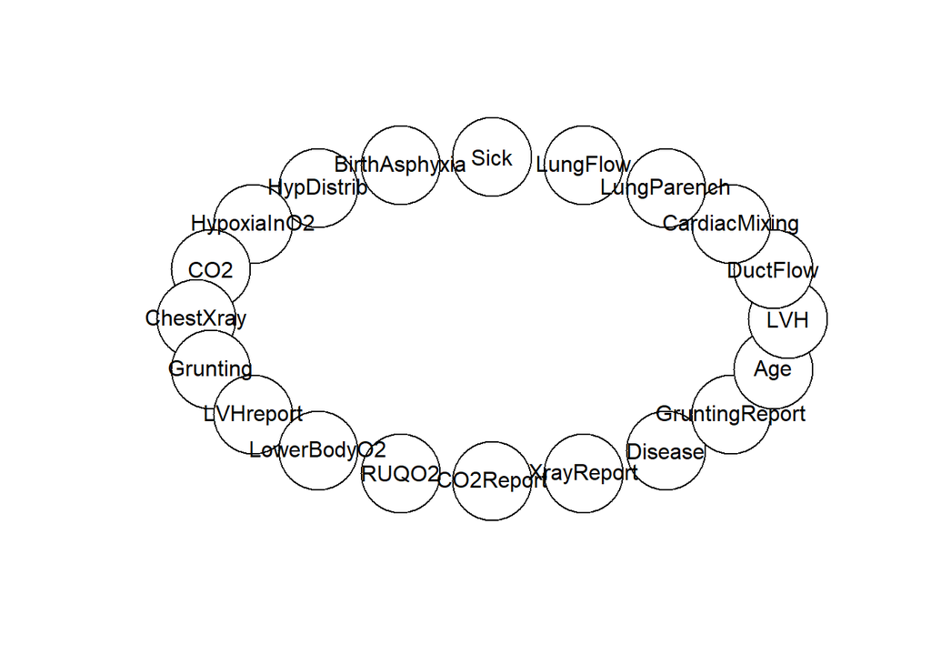

```r
plot(dag)
```

You can see that the DAG has no arcs, and each variable is a node. The next step will be to add directionality. Because the CHILD network is expertly defined, we can simply set the arcs. Once the structure is defined, we can also call the network structure in modelstring form.

```r
dag <- set.arc(dag, from = "BirthAsphyxia", to = "Disease")
dag <- set.arc(dag, from = "Disease", to = "Age")
dag <- set.arc(dag, from = "Disease", to = "LVH")
dag <- set.arc(dag, from = "Disease", to = "DuctFlow")
dag <- set.arc(dag, from = "Disease", to = "CardiacMixing")
dag <- set.arc(dag, from = "Disease", to = "LungParench")
dag <- set.arc(dag, from = "Disease", to = "LungFlow")
dag <- set.arc(dag, from = "Disease", to = "Sick")
dag <- set.arc(dag, from = "LVH", to = "LVHreport")
dag <- set.arc(dag, from = "DuctFlow", to = "HypDistrib")
dag <- set.arc(dag, from = "CardiacMixing", to = "HypDistrib")
dag <- set.arc(dag, from = "CardiacMixing", to = "HypoxiaInO2")
dag <- set.arc(dag, from = "LungParench", to = "HypoxiaInO2")
dag <- set.arc(dag, from = "LungParench", to = "CO2")
dag <- set.arc(dag, from = "LungParench", to = "ChestXray")
dag <- set.arc(dag, from = "LungParench", to = "Grunting")
dag <- set.arc(dag, from = "LungFlow", to = "ChestXray")
dag <- set.arc(dag, from = "Sick", to = "Grunting")
dag <- set.arc(dag, from = "HypDistrib", to = "LowerBodyO2")
dag <- set.arc(dag, from = "HypoxiaInO2", to = "LowerBodyO2")
dag <- set.arc(dag, from = "HypoxiaInO2", to = "RUQO2")
dag <- set.arc(dag, from = "CO2", to = "CO2Report")
dag <- set.arc(dag, from = "ChestXray", to = "XrayReport")
dag <- set.arc(dag, from = "Grunting", to = "GruntingReport")

# Step 2: get the network structure
modelstring(dag)
```

[output not shown]

The modelstring form is hard to read. We can also generate a simple plot of the structure.

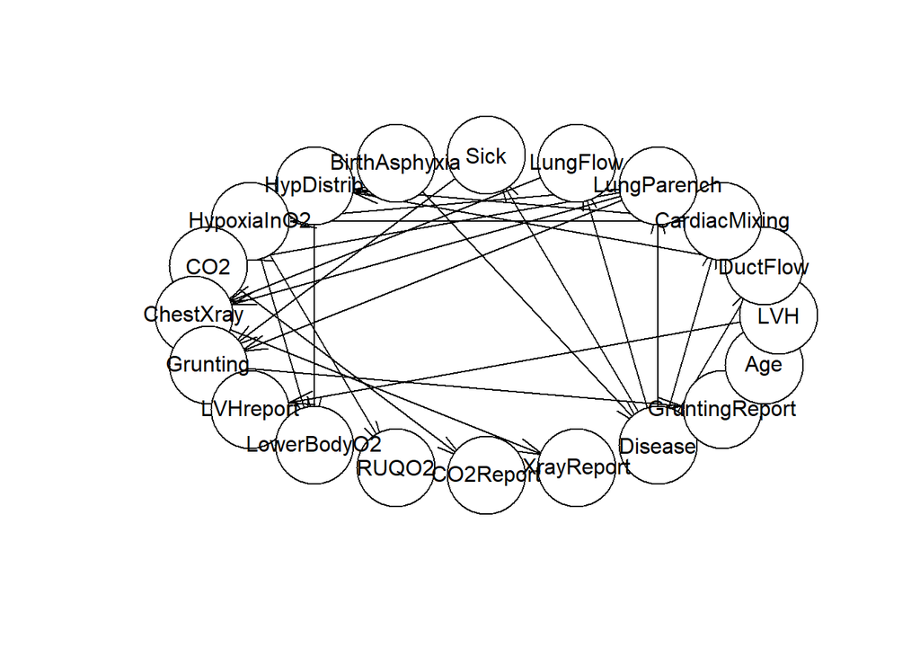

```r
plot(dag)
```

The DAG shows directionality now, but needs to be parameterized. The most useful method for this network is to parameterize using the CHILD data itself. We can easily parameterize using bn.fit. The ISS is the imaginary sample size, for which R will run the specified number of Monte Carlo simulations.

```r
# Parametrize using provided data, estimating conditional probabilities
bn.bayes2 <- bn.fit(dag, data = dats, method = "bayes", iss = 250)
```

Now that the model is parameterized, we can look up some conditional probability tables by variable.

```r
# CPT for node 13: chest x-ray
bn.bayes2$ChestXray
```

```
##
##   Parameters of node ChestXray (multinomial distribution)
##
## Conditional probability table:
##
## , , LungFlow = High
##
##            LungParench
## ChestXray     Abnormal  Congested     Normal
##   Asy/Patch 0.05347691 0.11272390 0.01256417
##   Grd_Glass 0.34586603 0.37955528 0.03368370
##   Normal    0.23252418 0.07103150 0.16568076
##   Oligaemic 0.33272495 0.04045707 0.01036421
##   Plethoric 0.03540792 0.39623224 0.77770716
##
## , , LungFlow = Low
##
##            LungParench
## ChestXray     Abnormal  Congested     Normal
##   Asy/Patch 0.69556740 0.16132333 0.02297547
##   Grd_Glass 0.05329520 0.47135061 0.02190129
##   Normal    0.05563499 0.05695771 0.15644208
##   Oligaemic 0.13635773 0.23499318 0.77839112
##   Plethoric 0.05914468 0.07537517 0.02029003
##
## , , LungFlow = Normal
##
##            LungParench
## ChestXray     Abnormal  Congested     Normal
##   Asy/Patch 0.77517881 0.09654395 0.03287104
##   Grd_Glass 0.05838005 0.60706236 0.01585014
##   Normal    0.05838005 0.07625845 0.88877882
##   Oligaemic 0.06185966 0.03906837 0.02800793
##   Plethoric 0.04620143 0.18106687 0.03449207
```

```r
# CPT for node 14: grunting
bn.bayes2$Grunting
```

```
##
##   Parameters of node Grunting (multinomial distribution)
##
## Conditional probability table:
##
## , , Sick = no
##
##         LungParench
## Grunting   Abnormal  Congested     Normal
##      no  0.39253973 0.76352642 0.94372558
##      yes 0.60746027 0.23647358 0.05627442
##
## , , Sick = yes
##
##         LungParench
## Grunting   Abnormal  Congested     Normal
##      no  0.20711907 0.59176985 0.79333882
##      yes 0.79288093 0.40823015 0.20666118
```

Spieghalter, et al, state that the diseases being evaluated include six possible conditions that are mutually exclusive and exhaustive. The authors state that the level of oxygen in the lower body is directly related to the underlying level when breathing oxygen and that the cardiac mixing also influences hypoxia (page 221). It is important to understand this, as this network is a diagnostic tool, and we are assuming that the child is being evaluated for which disease is the most likely, not the likelihood of overall disease. With this information in mind, I generated a plot about the most likely diagnoses given birth asphyxia. Using an ISS of 250, the highest probability of disease is TGA.

```r
# run separately, evaluate marginal probabilities and figure out which is highest.
cpquery(bn.bayes2, event = (Disease == "Lung"), evidence = (LowerBodyO2 == "5-12") & (XrayReport == "Plethoric"))
```

```
## [1] 0.03798768
```

```r
cpquery(bn.bayes2, event = (Disease == "TGA"), evidence = (LowerBodyO2 == "5-12") & (XrayReport == "Plethoric"))
```

```
## [1] 0.602537
```

```r
cpquery(bn.bayes2, event = (Disease == "PAIVS"), evidence = (LowerBodyO2 == "5-12") & (XrayReport == "Plethoric"))
```

```
## [1] 0.1177062
```

```r
cpquery(bn.bayes2, event = (Disease == "Fallot"), evidence = (LowerBodyO2 == "5-12") & (XrayReport == "Plethoric"))
```

```
## [1] 0.1463178
```

```r
cpquery(bn.bayes2, event = (Disease == "TAPVD"), evidence = (LowerBodyO2 == "5-12") & (XrayReport == "Plethoric"))
```

```
## [1] 0.0629845
```

```r
cpquery(bn.bayes2, event = (Disease == "PFC"), evidence = (LowerBodyO2 == "5-12") & (XrayReport == "Plethoric"))
```

```
## [1] 0.0250501
```

```r
cpquery(bn.bayes2, event = (Disease == "Lung"), evidence = (LowerBodyO2 == "12+") & (XrayReport == "Plethoric"))
```

```
## [1] 0.05460751
```

```r
cpquery(bn.bayes2, event = (Disease == "TGA"), evidence = (LowerBodyO2 == "12+") & (XrayReport == "Plethoric"))
```

```
## [1] 0.6039604
```

```r
cpquery(bn.bayes2, event = (Disease == "PAIVS"), evidence = (LowerBodyO2 == "12+") & (XrayReport == "Plethoric"))
```

```
## [1] 0.1314985
```

```r
cpquery(bn.bayes2, event = (Disease == "Fallot"), evidence = (LowerBodyO2 == "12+") & (XrayReport == "Plethoric"))
```

```
## [1] 0.1134021
```

```r
cpquery(bn.bayes2, event = (Disease == "TAPVD"), evidence = (LowerBodyO2 == "12+") & (XrayReport == "Plethoric"))
```

```
## [1] 0.09556314
```

```r
cpquery(bn.bayes2, event = (Disease == "PFC"), evidence = (LowerBodyO2 == "12+") & (XrayReport == "Plethoric"))
```

```
## [1] 0.03114187
```

We can also now visualize information on the network. We can use basic plotting (as we did above, which was extremely hard to read) or use a more advanced plot available within graphviz. Using graphviz, we can mimic the network provided in the reference paper.

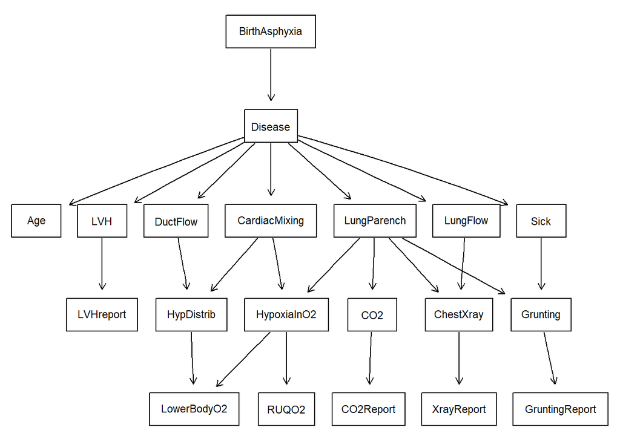

```r
graphviz.plot(dag)
```

The visualizations can be highly customized. But more importantly, we can now visualize some of the parameters. Let’s take a look at overall probability first.

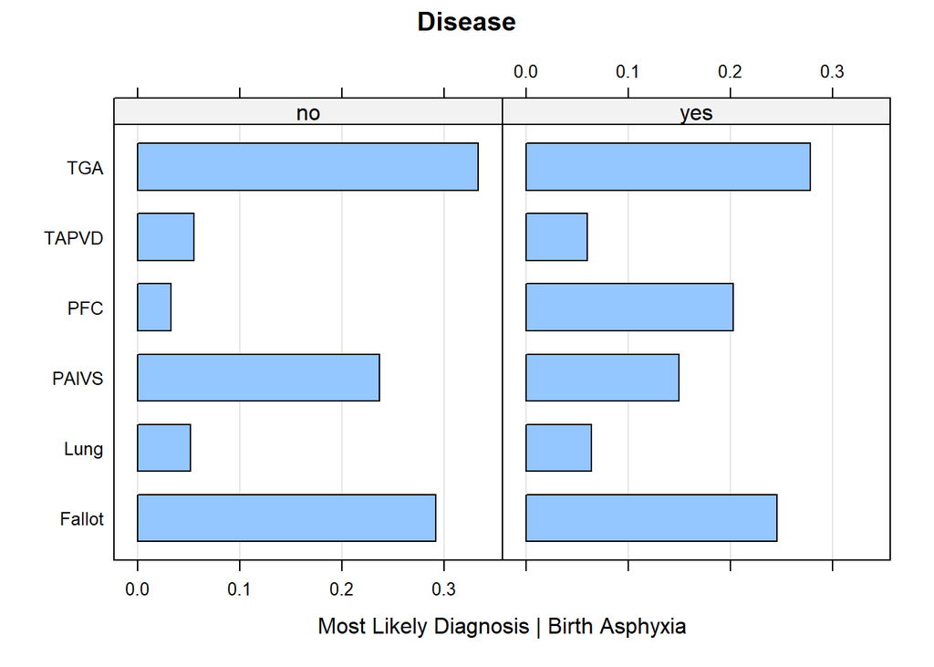

```r
# Visualize some of the parameters
# Recall that the model is bn.bayes2 <- bn.fit(dag, data = dats, method = "bayes", iss = 250)

bn.fit.barchart(bn.bayes2$Disease, main = "Disease",
                xlab = "Most Likely Diagnosis | Birth Asphyxia", ylab = "")
```

We can then set evidence and start to compare changes to the network graph. While the size of this graph is not conducive to an actual diagnostic setting, it still shows the capability of a BN to visualize the changes in probability by variable, which is extremely useful. We can also run queries to show the conditional probabilities of each outcome, which is again extremely useful.

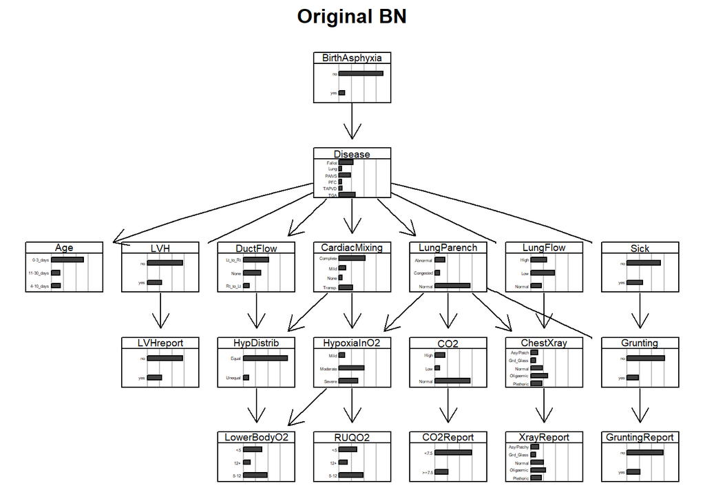

```r
# Take a look at original Bayesian Network with probabilities
# str(dats)

graphviz.chart(bn.bayes2, grid = TRUE, main = "Original BN")
```

```r
# Set Evidence to feed into the network graph
unique(dats$XrayReport)
```

```
## [1] Grd_Glass  Asy/Patchy Normal     Oligaemic  Plethoric
## Levels: Asy/Patchy Grd_Glass Normal Oligaemic Plethoric
```

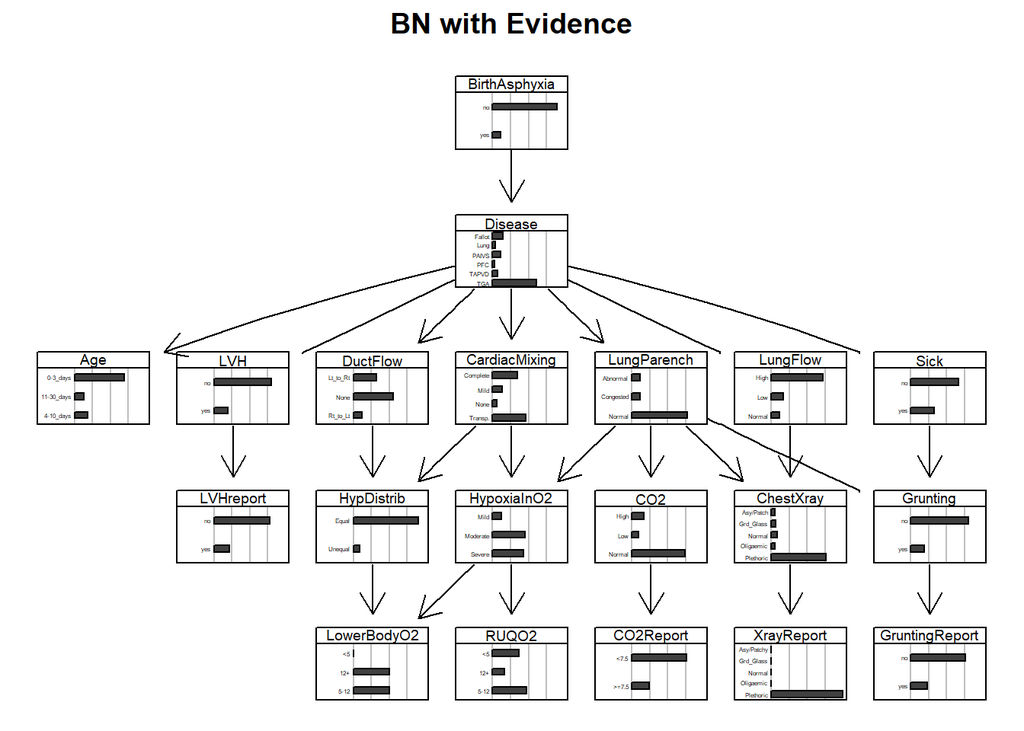

```r
junction <- compile(as.grain(bn.bayes2))
jedu <- setEvidence(junction, evidence = list(LowerBodyO2 = c("5-12", "12+"), XrayReport = "Plethoric"))

# Absorb the information above into a graph
graphviz.chart(as.bn.fit(jedu, including.evidence = TRUE), grid = TRUE,
               main = "BN with Evidence")
```

```r
# “lower body O2 < 5” and “X-ray report = oligaemic”; child is “not grunting”,

unique(dats$LowerBodyO2)
```

```
## [1] 5-12 12+  <5
## Levels: <5 12+ 5-12
```

```r
unique(dats$Grunting)
```

```
## [1] no  yes
## Levels: no yes
```

```r
cpquery(bn.bayes2, event = (Disease == "Lung"), evidence = (LowerBodyO2 == "<5")
        & (XrayReport == "Oligaemic") & (Grunting == "no"))
```

```
## [1] 0.01377727
```

```r
cpquery(bn.bayes2, event = (Disease == "TGA"), evidence = (LowerBodyO2 == "<5")
        & (XrayReport == "Oligaemic") & (Grunting == "no"))
```

```
## [1] 0.1163594
```

```r
cpquery(bn.bayes2, event = (Disease == "PAIVS"), evidence = (LowerBodyO2 == "<5")
        & (XrayReport == "Oligaemic") & (Grunting == "no"))
```

```
## [1] 0.3292683
```

```r
cpquery(bn.bayes2, event = (Disease == "Fallot"), evidence = (LowerBodyO2 == "<5")
        & (XrayReport == "Oligaemic") & (Grunting == "no"))
```

```
## [1] 0.4171633
```

```r
cpquery(bn.bayes2, event = (Disease == "TAPVD"), evidence = (LowerBodyO2 == "<5")
        & (XrayReport == "Oligaemic") & (Grunting == "no"))
```

```
## [1] 0.01330109
```

```r
cpquery(bn.bayes2, event = (Disease == "PFC"), evidence = (LowerBodyO2 == "<5")
        & (XrayReport == "Oligaemic") & (Grunting == "no"))
```

```
## [1] 0.04252734
```

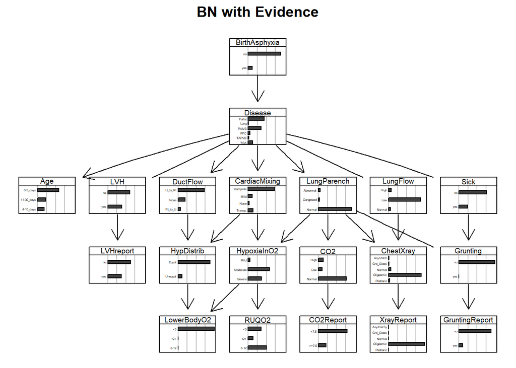

```r
# Visualize this on the network

jedu1 <- setEvidence(junction, evidence = list(LowerBodyO2 = "<5",
                                               XrayReport = "Oligaemic",
                                               Grunting = "no"))

# Absorb the information above into a graph

graphviz.chart(as.bn.fit(jedu1, including.evidence = TRUE), grid = TRUE,
               main = "BN with Evidence")
```